# BOSTON MEDICAL CENTER MICU AND PULMONARY COVID-19 BEST PRACTICES

03 April, 2020

This document was developed for internal use at Boston Medical Center. These are not recommendations nor are they guidance for use outside of BMC. Please check that you have the latest version of this document [here](https://www.bumc.bu.edu/pulmonary/). The latest versions of BMC algorithms and policies can be found [here](https://www.bmc.org/covid-19-information-employees/). Questions/concerns should be directed to Dr. Allan Walkey (alwalkey@bu.edu)

# RAPID MANAGEMENT OVERVIEW

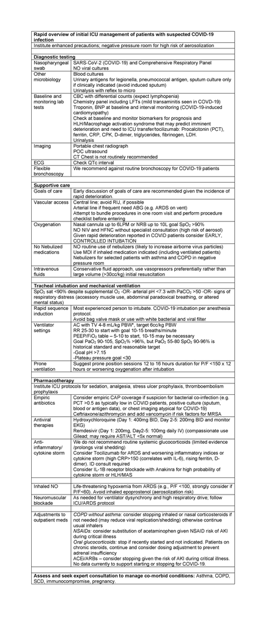

# CLINICAL COURSE PRIMER

SARS-CoV-2 (the virus that causes COVID-19) is a coronavirus. These are large, enveloped, single-strand RNA viruses. Summary of available data:

Incubation period

- 4 days (range 2-7)

Typical symptoms

- Fever 89% but only 44% at time of admission
- Cough 68%, productive in 34%
- Dyspnea 31%
- Anosmia 30%
- Sore throat 14%
- Nasal congestion 5%
- Diarrhea 4%

Severity

- 80% of patients with mild symptoms
- 20% require hospitalization
- 5% require ICU for ARDS (20-30% of hospitalized patients)
- Mortality: Age >60 years 3.6%, 70-79 years 8%, >80 years 14.8%, Respiratory failure/shock/multi-organ dysfunction 50%

Timeline

- Hospitalized ~8 days after exposure
- Respiratory failure ~12 days after exposure, 10 days after onset of dyspnea (late but rapid deterioration is characteristic feature)
- Cardiac injury ~17 days (increased incidence of cardiac arrest, cardiomyopathy)  
  -Viral shedding ~20 days after exposure

Lab abnormalities

- Lymphopenia (83%)
- CRP >10mg/l (61%) - associated with poor survival
- PCT <0.5 (94%)
- ALT/AST>40 (22%)
- Elevated ferritin, LDH, and troponin

# PHYSICAN ARRIVAL

## General Suggestions

- Watch the [Donning/Doffing video](https://www.bmc.org/covid-19-information-employees/screening-and-testing) multiple times
- General PPE information is located [here](https://www.bmc.org/covid-19-information-employees/screening-and-testing)
- Practice donning/doffing
- Have a spotter
- Even in an emergency situation, taking time to apply appropriate PPE is essential to maintain the health of medical workers
- BMC command center: 617-414-6860
- Working Well Clinic
  - Send questions to Covid19WWC@bmc.org
  - [Employee exposure reference tool](https://internal.bmc.org/sites/default/files/docs/2020-03/COVID19%20Employee%20Exposure%20Response%20Flow%20Chart_V2.pdf) Only available when using the VPN or on campus

## Personal Care Checklist

- Have you been fit tested for N-95? Have you shaved?
- Have you received your flu vaccination?
- Are you sick?
- Hungry? Thirsty? Empty bladder?
- Have you removed all jewelry?
- All items (stethoscope, badge, pager, phone, pen, papers) removed from pockets?
- Cell phone: consider bringing a transparent bag to store and avoid contaminating your cell phone.
- Shoes impermeable to liquids?
- Scrubs and underwear only as bottom layer? (Scrubs are available MICU A in the charge nurse office)
- Hair pulled back?

## Enhanced PPE

Enhanced PPE consists of N95 mask or PAPR, face shielf, gown and double gloves.

Please review video for donning and doffing PPE on the [BMC website](https://www.bmc.org/covid-19-information-employees/screening-and-testing). These guidelines may change, and the most updated version will be there.

In addition to using enhanced precautiosn in the ICU, all employees must wear a hospital-issued mask continuously throughout their shifts when at BMC where clinical care is provided, and when delivering home care. When entering a BMC clinical building you will be given a mask and at the end of the shift, the mask will be disposed of upon exiting the building

### Donning steps

- Perform hand hygiene (alcohol hand rub or soap and water)
- Don inner gloves (choose usual size, inspect for tears or holes)
- Don isolation gown, putting thumb through hole at end of arm sleeve and securing gown at neck and waist
- Don second set of gloves (consider one size up from usual), extend to cover wrist of gown
- Don N95 mask
  - Bottom strap below ears on your neck
  - Upper strap is placed toward the crown of head (no crossed straps) - Mold nose piece of N95 or surgical mask over bridge of nose to obtain tight seal
    - *If wearing glasses, perform a moderate exhalation test around seal to minimize fogging of glasses*
- Don goggles/face shield (shield must extend below chin)
- Now ready to care for patient

### Doffing steps

- Remove outer gloves and discard
  - Grasp outer glove with opposite hand, peel off and hold in double gloved hand
  - Slide fingers under the outer glove at wrist and peel off
- Remove gown and discard
  - Grab gown at shoulders, tear or untie neck and peel away and down, touching inside only
  - Remove, rolling inside out
- Sanitize inner gloves with alcohol hand rub or soap and water
- Remove inner gloves and discard
- Exit patient room
- Hand hygiene on bare hands
- Don a new pair of gloves
- Remove goggles/face shield
  - Remove touching only the back, avoid the front aspect
  - If using reusable face shield, wipe it down with purple SuperSani wipe
- Sanitize gloved hands with alcohol hand rug or soap and water
- Remove gloves and discard
  - Grasp outside of the glove with opposite gloved hand, peel off and hold in gloved hand
  - With other hand slide fingers under the glove at wrist and peel off
- Sanitize bare hands with alcohol rub or soap and water
- If continuing to see COVID-19 patients or PUI, re-don face shield, walk to next patient room and don new gloves and gown (keep face mask in place)
- If finished with patient care
- Remove N95 respirator
  - **DO NOT TOUCH FRONT OF MASK** (contaminated)
  - Grasp the bottom strap, pull over head and allow to dangle
  - Remove top strap and drop into waste bin
- Use alcohol rub on bare hands, and then wash hands thoroughly

## Staying Clean in the Room

- Disposable Stethoscope use
  - Enter the room, immediately put hand sanitizer on your glove and clean stethoscope. (Do at the beginning, rather than after using it because it’s hard to be sure you’re not just continually recontaminating it with your dirty gloves)
- Putting on and taking off the stethoscope
  - It’s tricky with the large face shields. Grab the scope at the base of the Y to put it in your ears. To remove it, trace your hands up from the bell of the scope to the base of the Y and spread the prongs that way to remove it
- Use the interpreter iPad, rather than phone
  - Patients use the phone

# INITIAL ICU EVALUATION

## SARS‐CoV‐2 (COVID‐19) and Comprehensive Respiratory Panel Testing

- BMC now has in-house COVID-19 testing with expected turnaround time to be 6-8 hours after receipt by the laboratory
- Following [hospital guidelines](https://www.bmc.org/covid-19-information-employees/screening-and-testing), use the EPIC COVID-19 Order Panel with the preferred/high risk testing selected to test for both SARS‐CoV‐2 (COVID‐19) and the Comprehensive Respiratory Panel from the same nasopharyngeal sampling.
- Since nasopharyngeal swabs often generate a strong cough reflex, enhanced PPE are recommended.
- *For safety reasons, specimens from a patient with suspected or documented COVID-19 should not be submitted for viral culture.*

## Laboratory Testing of Patients with Severe COVID-19

Severe COVID-19 is defined as respiratory failure (e.g. dyspnea, hypoxia, or >50% lung involvement on imaging within 24-48 hours) or critical ilness (e.g. shock, or multi-organ dysfunction)

### COVID-19 specific tests

- Chemistry panel
- LFTs including albumin
- CBC with differential (lymphopenia most common)
- Procalcitonin (normal in 95% of patients; more likely to be elevated in ICU patients)
- Ferritin
- Triglycerides
- Fibrinogen
- CRP
- ESR
- Troponin
- LDH
- CPK
- D-dimer
- PT

### Rationale

- Evidence suggests that a subgroup of patients with severe COVID-19 develop a cytokine storm syndrome similar to secondary hemophagocytic lymphohistiocytosis (sHLH) or macrophage activation syndrome-type syndrome. These syndromes may include worsening respiratory failure, other organ failure, increasing ferritin, CRP, decreasing platelet counts, or increasing erythrocyte sedimentation rate. **It is unclear if immunosuppression in this subset may improve mortality**, but identification of these syndromes warrants consideration of biologics agents and discussion with ID. The [Hscore](https://www.mdcalc.com/hscore-reactive-hemophagocytic-syndrome) may be useful to identify patients for which to consider immunosupression. NOTE: Therapies are experimental in COVID-19 infection (see below)
- CRP, ferritin, LDH, D-dimer are markers that may track with disease severity and prognosis
- Regular repeat testing of CBC, Chemistry panel, LFTs, procalcitonin, ferritin, triglycerides, fibrinogen, CRP, ESR, LDH, d-dimer, and troponin to track disease severity
- Check troponin/EKG in a deteriorating patient to assess for cardiomyopathy, and conduction disturbance. Higher than expected cardiovascular deaths (VT/VF, asystole) have been seen in COVID-19 patients.

### Discontinuation of precautions after a negative test

- The Precuations banner in EPIC will automatically discontinue when a negative nasopharyngeal swab test result returns and a patient has none of the following: fever, high procalcitonin, lymphopenia, a COVID-19 contact, travel history, no alternative virus present on viral respiratory panel. **However, the initial nasopharyngeal swab test may be a false negative**. The current test is not 100% sensitive and the chance of a positive test decreases over time in those with COVID-19. Precaution status will remain even though the banner is removed as long as an active order for precautions remains in EPIC.
- **Prior to removing the precuations order, contact the COVID-19 ID team ([Pager 5236](https://directory.bmc.org/webxchange/ViewProfile.aspx?profileid=COVID19) )**.
- In addition, in intubated patients with an initial negative nasopharyngeal swab test result, send paired tracheal aspirate sample to state and a repeat nasopharyngeal swab sample
  - COVID-19 order set “Additional Testing” section

## Imaging

- Portable chest x-rays are **sufficient** in most cases for assessing the patient’s lung parenchyma
  - Bilateral patchy infiltrates are most common (may evolve rapidly)
- Lung POC ultrasound [Peng et al.](https://link.springer.com/article/10.1007%2Fs00134-020-05996-6)
  - Pleural line thickening and irregularity
  - B-lines
  - Consolidations
  - A-lines appear in recovery phase
  - Pleural effusions are uncommon and alternative diagnoses should be considered
- Routine Chest CT is **NOT recommended**
  - Common findings include ground-glass opacification with or without consolidative abnormalities, consistent with viral pneumonia [Kanne et al.](https://pubs.rsna.org/doi/10.1148/radiol.2020200527)
    - *CT Chest should only be considered in specific cases where there is diagnostic uncertainty and/or it will lead to changes in clinical management when other diagnostic methods are unreliable. CT Chest can overwhelm resources (e.g., need for transport, cleaning of CT scan suite, nursing effort), and increase risk of exposure.*

## Bronchoscopy

- Bronchoscopy is **NOT recommended** or necessary for the purpose of ruling COVID-19 in or out and should be avoided to minimize risk of aerosolization.
- Bronchoscopy should only be done if it will change clinical management and if at all possible should be completed in a negative pressure room.

# ORGAN DYSFUNCTION MANAGEMENT

Supportive care, and first **DO NO HARM**

## Acute Respiratory Failure

- Use a conservative fluid approach, use vasopressors over large volume (>30cc/kg) initial resuscitation [FACTT Algorithm](http://www.ardsnet.org/files/factt_algorithm_v2.pdf)
- Be aware of reported hypercapnia (PaCO2 >45) and respiratory failure without symptoms of dyspnea, possibly related to central effects of virus
- Avoid NIV, HFNC and nebulizers
  - Highly aerosolizing and risk viral spread
  - In ARDS/hypoxemic respiratory failure NIV is generally ineffective
  - Although WHO and SCCM guidelines make weak recommendations for HFNC in select patients, we feel that the risk of aerosolization to healthcare workers, the observed rapid decompensation of COVID-19 patients and the risk of patient self-induced lung injury [(P-SILI)](https://www.ncbi.nlm.nih.gov/pubmed/27626833/) outweigh the potential benefits at this time.
- Nasal cannula up to 6Lpm or NRB up to 10L goal SpO2 sat >90% after initially stabilized
  - During transport, use nasal cannula for oxygen administration or NRB if additional oxygen is needed
  - Patients being transported with oxygen should wear droplet masks during transport over oxygen tubing
  - If inability to effectively oxygenate (SpO2 sat <90%) or ventilate (arterial pH <7.3 with PaCO2 > 50), and/or if patient has signs of respiratory distress (accessory muscle use, abdominal paroxysmal breathing), then strongly consider **CONTROLLED ELECTIVE** intubation
  - Make sure anesthesia and respiratory therapy are aware pt is COVID-19 + or PUI
    - Clinician hand don appropriate PPE
    - Ensure utilization of appropriate filters during bag mask ventilation (e.g. white bacterial/viral ENVE filter between the bag and the mask) and mechanical ventilation (e.g. PALL or N100 HEPA filters)
- Consider central line (avoid RIJ to leave for renal replacement therapy access) and a-line (if frequent abg) *at same time as intubation to minimize patient contacts*

## ARDS Management

- The most common severe complication of COVID-19 is ARDS
- ARDS Definition: Bilateral infiltrates PaO2/FiO2 <300 or SatO2/FiO2 <315, PEEP 5 or more, acute onset, not explained by heart failure
  - Preliminary data suggest that 15-20% of hospitalized patients will develop ARDS [Guan et al.](https://www.nejm.org/doi/10.1056/NEJMoa2002032) [Wang et al.](https://jamanetwork.com/journals/jama/fullarticle/2762997)
  - Time from illness onset to ARDS 12 days
- **Mainstay of ARDS treatment is mechanical ventilation designed to not cause further injury**
  - [ARDSnet Protocol & PEEP/FIO2 TABLES](http://www.ardsnet.org/files/ventilator_protocol_2008-07.pdf)
  - [ARDSnet IBW TABLES](http://www.ardsnet.org/files/pbwtables_2005-02-02.pdf)
- We recommend ventilator settings that target the following
  - Good enough oxygenation (ideally PaO2 90-105, SpO2% >96% given recent [evidence](https://www.nejm.org/doi/full/10.1056/NEJMoa1916431?query=featured_home), but PaO2 55-80 is historical standard and a reasonable target)
  - Good enough ventilation (pH >7.15)
  - Initial settings
    - Volume Assist Control with tidal volume 4-8cc/kg Predicted body weight
    - 5-10 PEEP, may need titration to 10-15 (see above ARDSnet table)
      - evaluate for improvement in oxygen at risk for hypotension with PEEP increases
    - RR enough to meet estimated pre-intubation minute ventilation (MV = TV * RR, goal 10-15 for sick patients, then readjust, usually will need RR 25-30 to start)
    - Goal plateau pressure <30
  - In patients requiring escalating sedative infusions for ventilator dys-synchrony, consider use of Airway Pressure Release Ventilation (APRV), which may facilitate ventilator synchrony and has been shown to lower sedative requirements/avoid need for neuromuscular blockade
    - Caution should be taken for use of APRV in patients with strong respiratory efforts generating large trans-alveolar pressures (i.e., Inspiratory Pressure [Phigh]-respiratory effort negative pressure may cause additional lung injury).
- ARDS adjunctive therapies
  - Prone position [Guerin et al.](https://www.nejm.org/doi/full/10.1056/nejmoa1214103) ([BMC Protocol](https://bostonmedicalcenter.policytech.com/dotNet/documents/?docid=1781) BMC login required)
    - Recommend if P/F <150 for 12 hours or worsening oxygenation after intubation without other cause
    - Prone position for 12-16 hours daily provides mortality benefit through reduced lung injury
    - Positive criteria for stopping prone treatment:
      - PaO2:FiO2 ratio of ≥150 mm Hg with PEEP of ≤10 and an FiO2 of ≤0.6 in the supine position at least 4 hours after the end of the last prone session
    - Negative criteria for stopping prone treatment (either criteria is sufficient alone to discontinue prone treatment):
      - Decrease in the PaO2:FiO2 ratio of more than 20% relative to the ratio in the supine position, before two consecutive prone sessions
      - Complications occurring during a prone session and leading to its immediate interruption (e.g., extubation, main-stem bronchus intubation, endotracheal tube obstruction, hemotpysis, hemodynamic instability, worsening hypoxemia, cardiac arrest, bardycardia)
      - **NOTE**: prone position patients **do NOT** routinely require neuromuscular blockade
  - Inhaled NO
    - adjunctive therapy designed to improve oxygenation. No known mortality benefit. It complicates routine vent FiO2 changes, so recommend only for life-threatening hypoxemia, e.g., consider if P/F <100, strongly consider if P/F<60. Watch for renal failure complication. Avoid inhaled epoprostenol dur to aerosolization.
  - Neuromuscular blockade
    - As needed for ventilator dyssynchrony and high respiratory drive resulting in injurious tidal volumes, airway pressures, double-triggering, breath stacking, or inability to oxygenate or ventilate
    - **Analgesia, sedation, and amnesia are absolutely necessary PRIOR to inducing paralysis**
    - Discuss with pharmacy about optimal neuromuscular blockade agent given potential shortages and medication interactions
  - Corticosteroids: Routine use of steroids is not indicated for the treatment of COVID-19. Corticosteroids can be used to treat conditions generally requiring corticosteroids (e.g., 0.5 mg/kg prednisone in moderate-severe COPD or asthma exacerbation, or hydrocortisone 50mg qid in refractory septic shock) in COVID suspects. Please consult with ID and pulmonary/critical care to discuss risks/benefits if high dose steroids are being considered. Risk of 3-fold increased time to viral clearance [evidence from MERS](https://doi.org/10.1164/rccm.201706-1172OC), hyperglycemia, and psychosis.
    - Balance societal risk with potential individual pt benefit
    - In life-threatening severe ARDS with refractory hypoxemia, consider use of steroids on an individual basis, especially with concomitant refractory shock, as steroids improve oxygenation and blood pressure.
    - Recent (very low quality) observational [JAMA IM paper](https://jamanetwork.com/journals/jamainternalmedicine/fullarticle/2763184) shows potential benefit in COVID-19; also Observational study in MERS (RR 0.75 95% CI 0.52–1.07) and [Cochrane meta-analysis](https://www.cochranelibrary.com/cdsr/doi/10.1002/14651858.CD004477.pub3/full) of non COVID ARDS 68 trials (RR 0.77, 95% CI 0.57 to 1.05) show similar effect estimate of potential benefit, and recent trial in ARDS showed survival benefit in non-COVID-19 ARDS: N=277 36 vs 21% 60-day mortality, p=0.0047 with Dexamethasone 20mg daily for 5 days then 10mg for 5days.

## Weaning and Extubation

Patients with improvement in the reason that they required mechanical ventilation should be considered for a weaning trial. In addition to clinical improvement, guidelines for consideration of a weaning trial include:

- Ability to initiate own breaths
- O2 saturation >90% on 40% oxygen or less, or PaO2/FiO2 >150
- pH>7.25
- Hemodynamically stable on low dose, reliably down-titrating, or no vasopressors
- Minute ventilation requirements not excessive (e.g, <12Lpm, RR <30)
- Mental status with ability to protect airway (eg., GCS>8, but not a strict criterion) or not cause self-harm due to agitation
- Lack of excessive respiratory secretions (eg q2 hour secretion suctioning requirement)

### Spontaneous Awakening

Once patients are deemed ready for weaning, sedatives should be minimized/held and a spontaneous breathing trial (SBT) can be attempted.

### Spontaneous Breathing Trial

A SBT switches the patient to a pressure support mode of mechanical ventilation with low levels of pressure support (5-10ccH20) and PEEP (5) and allows them to breathe mostly on their own. When patients have completed ~2 hours of an SBT and still meet the criteria for consideration of a weaning trial (stable respiratory status, non-copious secretions, and sufficient mental status), then consider the patient for extubation.

### Risks and benefits of a cuff leak test

A cuff leak test may identify patients at high risk for post-extubation stridor that increases risks for re-intubation (~50% sensitivity, 95% specificity). Treatment with corticosteroids 4-6 hours prior to extubation can reduce risks of re-intubation from post-extubaton stridor. Pooled studies suggest that that risk of re-intubation is reduced from 4.2% to 2.4% (ARR 1.8% 0.7, 2.5%) through use of a cuff leak test and corticosteroids to reduce laryngeal edema. However, a cuff leak test may aerosolize virus and routine corticosteroids may delay viral clearance and increase replication.

Given the relatively *low risks for re-intubation due to laryngeal edema*, the *risks of aerosolization from cuff leak test and general avoidance of aerosolizing procedures*, and the *risk of routine prophylactic steroid administration to all patients prior to extubation*, **we recommend extubation without a prior cuff leak test**. If a patient has post-extubation stridor without severe respiratory distress, they can be trialed on heliox, inhaled racemic epinephrine, and methylprednisolone IV 40mg. We will continue to evaluate this recommendation as new evidence accumulates.

### Extubaton procedure recommendations

1. For patients who have been receiving MDI bronchodilators, administer dose approximately 15 minutes prior to extubation
2. Explain sequence of events to patient and the preference that they swallow oral secretions if possible
3. Place oxygen mask over patient’s forehead at 10lpm Place surgical mask over oxygen mask
4. Suction any secretions above cuff
5. Extubate
6. Quickly slide oxygen mask and covering surgical mask into place over mouth and nose
7. Do not encourage coughing
8. Do not use BPAP or HFNC

## Shock Management

- Evaluate for underlying cause of shock (septic, cardiogenic, obstructive, adrenal insufficiency) – TTE, capillary refill, central venous O2 sat
- Preferential use of vasopressors rather than large volume fluid resuscitation to avoid exacerbating ARDS
- Initial vasopressor of choice norepinephrine, 1-30 mcg/min
  - Secondary vasopressor vasopressin 0.4 units if distributive shock
  - Consider epinephrine, or consideration of milrinone, dobutamine if cardiogenic component, cardiology consult
- Goal MAP 60 is associated with fewer complications than 65, but with similar outcomes
- Sedation (spontaneous awakening and breathing trials), Nutrition, Glucose, DVT-GI Prophylaxis all managed per standard ICU protocols.

# SEDATION/ANALGESIA/PARALYSIS

During the covid-19 pandemic, medications commonly used for analgesia, sedation, and paralysis at BMC may not be readily available (specifically continuous infusion sedatives). This section outlines the (1) various pharmacologic options to provide analgesia, sedation, and paralysis to our ventilated patients in the ICU, (2) proposes a practical framework that uses scheduled enteral or IV push medications to lessen the dose of continuous infusions to extend duration whenever clinically feasible, and (3) creates a fluid resource for clinicians that evolves based on currently available medications.

## Sedatives

### General Approach

Typically, patients should be provided the lowest level of sedation necessary to be comfortable and synchronous with the ventilator. However, since providers must appropriately don PPE before entering rooms of PUI or covid-19 positive patients, deeper levels of sedation may be necessary to maintain patient safety and reduce the number of assessments and prn doses needed. For most agents (excluding lorazepam) use a continuous infusion for the first 18-24 hours after intubation to assess overall sedation needs.

Following ~24 hours of continuous infusion to evaluate sedative requirements:

1. Initiate scheduled NG/OG or IV push sedation, if patient requires continuous infusion rates above thresholds as detailed below under “Specific Medications-Sedatives”
2. Defer initiation of scheduled NG/OG or IV push sedation if patient does not meet threshold criteria under “Specific Medications-Sedatives”, or if there is a plan to attempt extubation in the next 24-48 hours.
3. Discontinue scheduled NG/OG sedatives 12 hours before any planned extubation (if dexmedetomidine or ketamine not already started and available, consider initiating to in an effort to minimize benzodiazepine use and aid in extubation as these medication do not decrease respiratory drive).

### Sedative Medication Options

#### Propofol

First line

1. Initiate continuous infusion at 10 mcg/kg/min per Epic default order
2. If patient requires rate > 30mcg/kg/min initiate lorazepam 2mg NG/OG/IV push q6hrs or 64.8 mg NG/OG phenobarbital q8hr
3. If patient requires > 40mcg/kg/min then increase dose or frequency of NG/OG/IV push lorazepam/phenobarbital
4. Monitor: triglycerides q48-72 hours

#### Midazolam

Second line

1. Initiate continuous infusion at 2mg/hr per Epic default order
2. If patient requires rate > 5mg/hr for > 48 hours then start NG/OG lorazepam at 2mg NG/OG q6hrs or phenobarbital at 64.8 mg NG/OG q8hrs
3. If patient requires rate > 10 mg/hr for > 48 hours increase the dose or frequency of NG/OG lorazepam or phenobarbital
4. Monitor: Caution active metabolites are not cleared during renal insufficiency which may accumulate and cause excess sedation

#### Lorazepam

Third line infusion. First line NG/OG supplement and intermittent IV bolus.

1. Following intubation administer 2mg IV push to assess patient response to lorazepam.
   - If patients responds appropriately (Riker <4 for at least 30 mins) to single 2mg dose, consider 2mg q6h IV push dosing or initiation of continuous infusion at 0.5mg/hr
   - If during initial assessment (before leaving room after getting the patient settled) the patient requires >2 doses of IV push, then start continuous infusion at 1mg/hr
   - If patient requires rate > 2mg/hr for > 48 hours initiate lorazepam 2mg NG/OG q6hrs or 64.8 mg NG/OG phenobarbital q8hr
2. In patients with CrCl < 30 do not exceed continuous infusion 3mg/hr (~1mg/kg/d) due to risk of propylene glycol toxicity (due to vehicle of continuous infusion, not a concern for enteral lorazepam).
   - Recommend checking serum osm (to assess for osmolar gap) daily for any patient on continuous infusion > 48hrs or with CrCl < 30
   - Recommend checking serum osm (to assess for osmolar gap) for any patient who develops new anion gap or acute kidney injury while on lorazepam infusion

#### Dexmedetomidine

First line adjunct.

1. In general, dexmedetomidine is unlikely to provide deep levels of sedation. Therefore, in the current climate we recommend its use mainly as a 2nd line adjunct to other sedatives, or as a 24-48 hour bridge to wean benzodiazepines (infusion, scheduled IV push/NG/OG) to facilitate extubation.
2. Monitor: bradycardia

#### Ketamine

Second line adjunct.

1. Ketamine has both sedative- and analgesic-sparing properties
2. Consider use in patients requiring high dose continuous infusion propofol, or any continuous benzodiazepines, to decrease or eliminate benzodiazepine requirements
3. Ketamine is unlikely to replace benzodiazepines when using for vent synchrony

#### Phenobarbital

Third line adjunct.

1. For sedation following intubation, consider dosing of 260 mg IV x1, followed by 130 mg IV q6h
2. For assistance in weaning off a benzodiazepine infusion, consider starting dose of 130 mg IV q6h
3. If concerned for over sedation, recommend checking a phenobarbital level and hold further doses until level <30 mcg/mL. **NOT to be used as monotherapy sedation for paralysis**

#### Additional considerations

For patients requiring sedatives for increased agitation, consider scheduled neuroleptics and anti-epileptic ‘mood stabilizers’ as additional adjunctive medications, especially as continuous infusions are weaned. For patients with delirium while using continuous infusion benzodiazepines, consult with ICU pharmacist regarding the potential use of phenobarbital to completely replace benzos. **Note, the below medications are unlikely to benefit patients requiring high doses of sedatives for vent dyssynchrony.**

1. Quetiapine 50mg nightly (ICU delirium) or 25mg q6h (ATC agitation)
   - Check daily QTc if used as an adjunct, and avoid particularly if used with additional QTc-prolonging medications (hydroxychloroquine, azithromycin, methadone)
2. Valproate 250mg IV q6h

## Analgesia

### General Approach

Initiate all patients on continuous infusion of analgesia following intubation; if a patient can be managed on q6h IVP analgesics, that is preferred, however, uncommon.

Following 18-24 hours of continious infusion to evaluate analgesia requirements:

1. Initiate scheduled NG/OG analgesia if patient requires continuous infusion rates above thresholds as detailed below under “Specific Medications-Opioids”.
2. Defer initiation of scheduled NG/OG analgesia if patient does not meet criteria, or if there is a plan to attempt extubation in the next 24-48 hours.
3. Discontinue scheduled NG/OG analgesia 12 hours before any planned extubation to facilitate a successful SAT/SBT (see recommendations for dexmedetomidine and ketamine below).

### Analgesia Medication Options

#### Fentanyl

First line.

1. Initiate continuous infusion at 12.5-50mcg/hr per Epic default order
2. If patient requires rate > 150mcg/hr initiate hydromorphone 4mg NG/OG q6h
3. If patient requires rate > 200mcg/hr then increase dose or frequency of scheduled NG/OT hydromorphone

#### Hydromorphone

Use if fentanyl on shortage.

1. Initiate continuous infusion 0.25mg/hr per Epic default order
2. If patient requires rate > 1mg/hr initiate hydromorphone 4mg NG/OG q6h
3. If patient requires rate > 2mg/hr then increase dose or frequency of scheduled NG/OG hydromorphone
4. Hydromorphone is hepatically metabolized. In patients with moderate to severe liver dysfunction consider enteral dose reductions of 25%-50%

## Neuromuscular Blockade

1. In patients whom NMB is necessary (i.e., ventilator dyssynchrony causing high plateau pressures>30cm H2O or volumes>8cc/kg IBW; ventilator dyssynchrony causing hypoxemia) preferentially use intermittent NMB pushes over drips. Drips should be reserved for patients requiring more than q6hour pushes.
2. Please review with pharmacy the appropriate NMB based on availability, hepatic and renal function.
3. Note: patients in prone position do not necessarily require continuous neuromuscular blockage and need for NMB should be assessed individually based on ventilator synchrony.

# HOME MEDICATIONS

### ACE Inhibitors/ARBs

**Summary**: The decision to discontinue outpatient ACEi/ARBs should be made based on underlying cardiac comorbidities and the risk/benefit of discontinuation. In critically ill patients at risk for AKI (e.g., shock, multi-organ failure), it is reasonable to discontinue ACEi/ARBs at ICU admission. The associations between ACEi/ARBs and COVID-19 are unclear.

**Evidence**: There are hypotheses that ACEi/ARBs could improve [Gurwitz](https://onlinelibrary.wiley.com/doi/full/10.1002/ddr.21656) or worsen Fang et al. COVID-19 related outcomes. Patients with hypertension and diabetes are at increased risk for COVID-19 [Guan et al.](https://www.nejm.org/doi/10.1056/NEJMoa2002032) and COVID-19-related complications Zhou et al., but no studies have evaluated the specific association between ACEi/ARBs and COVID-19. The [AHA, ACC, and Heart Failure Society of America](https://www.acc.org/latest-in-cardiology/articles/2020/03/17/08/59/hfsa-acc-aha-statement-addresses-concerns-re-using-raas-antagonists-in-covid-19) recommend contination of ACEi/ARBs in patients with cardiovascular disease but that individualized decisions be made according to each patient’s hemodynamic status and clinical presentation.

### NSAIDs

**Summary**: In most patients, it is reasonable to discontinue NSAIDs at ICU admission given the risk of AKI and bleeding with NSAID use during critical illness. There are anecdotal reports of more severe disease among those taking NSAIDS prior to hospitalization, the significance of which is unclear. Consider substitution with acetaminophen if necessary.

**Evidence**: The association between NSAIDs and COVID-19 is unclear. On March 14th, 2020, The French health ministry updated guidelines stating that paracetamol should be used for the treatment of COVID-19-related fever and pain and that there have been reports of NSAID-related serious adverse events. [WHO](https://www.sciencealert.com/who-recommends-to-avoid-taking-ibuprofen-for-covid-19-symptoms) does not recommend avoiding NSAIDs for COVID-19 symptoms. In general, NSAIDS should be avoided in critically ill patients given risks of renal failure Hoste et al. and bleeding.

### Corticosteroids

**Summary**: The decision to discontinue systemic corticosteroids at the time of ICU admission should be based on underlying comorbidities and the risk/benefit of discontinuation rather than COVID-19 status. In those on choronic corticosteroids, consider adjustment of dose (“stress dose steroids”) to prevent adrenal insufficency. Consider discontinuing intranasal corticosteroids and inhaled corticosteroids in those with COPD who do not require these medications acutely (inhaled corticosteroids may enhance viral shedding)

**Evidence**: In a study of 84 patients with COVID-19 complicated by ARDS in Wuhan, China [Wu et al.](https://jamanetwork.com/journals/jamainternalmedicine/fullarticle/2763184), patients who recieved methylprednisolone were less likely to die in unadjusted analyses (HR 0.38 [95% CI 0.20-0.72]), not accounting for confounding by indication. A study of 309 patients with the related viral disease MERS [Arabi et al.](https://www.atsjournals.org/doi/full/10.1164/rccm.201706-1172OC) found no association between mortality and corticosteroid use but an increased risk of delayed respiratory tract clearance with corticosteroid use. WHO interim guidance from March 13th, 2020 recommends against routine administration of systemic corticosteroids for treatment of viral pneumoniaWHO.

### QTC prolonging medications

**Summary**: If Hydroxychloroquine is initiated, review home medications for QTC prolonging agents and consider the risk/benefit of continuing. The risk of QTC prolongation with hydroxychloroquine is generally low.

# TREATMENTS

All anti-viral therapies and immunomodulatory therapies are **EXPERIMENTAL** and based on pre-clinical data, expert opinion, small and emerging clinical studies and consensus statements. The WHO currently advices against the use of anti-viral therapy or corticosteroids outside of a clinical trial context.

## Antivirals

### Chloroquine/Hydroxychloroquine

**Summary**: The data for COVID-19 is based on [in-vitro data](https://www.nature.com/articles/s41422-020-0282-0) of efficacy against COVID-19 infection at drug concentrations achievable in humans and expert opinion from China based on reported clinical experience in 100 patients. Furthermore, we have clinical experience with these drugs in chronic inflammatory diseases where immunomodulatory effects are observed, plus they are low cost and generally safe. However, toxicity in acutely ill patients is unknown. Hydroxychloroquine may have less severe side effects than chloroquine [Weniger et al.](https://apps.who.int/iris/handle/10665/65773). The use of hydroxychloroquine in COVID-19 patients is experimental.

- Dosing: Hydroxychloroquine Day 1: 400mg BID, Day 2-5: 200mg BID
- Adverse effects: **severe hypoglycemia (rare), cardiomyopathy (rare), prolonged QTC (rare), macular degeneration**
- Monitoring: baseline EKG and blood glucose
  - If after initial dose the QTC is <410 and no other QTC prolonging medications are being administered, consider decreasing frequency of EKGs to reduce healthcare worker exposure

**Mechanism**: Chloroquine is a 9-aminoquinolone and a weak base. Intracellularly it accumulates in acidic organelles such as the endosome, Golgi and lysosomes. The proposed antiviral mechanisms of chloroquine and hydroxychloroquine are through inhibiting endosome-mediated viral entry or at the late stages of replication. Chloroquine can inhibit pH-dependent replication steps of several viruses including coronaviruses. Chloroquine may also have an immunomodulatory effect: it accumulates in macrophages and in in-vitro studies treatment with chloroquine decreased the secretion of IL-6 and TNFa.

### Remdesivir

**Summary**: Remdesivir demonstrates [in-vitro activity](https://www.nature.com/articles/s41422-020-0282-0) against COVID-19, [SARS-CoV](https://stm.sciencemag.org/content/9/396/eaal3653) (also murine model) and [MERS-CoV](https://stm.sciencemag.org/content/9/396/eaal3653). Human data is limited to the first patient treated for COVID-19 in Washington, ongoing clinical trials and limited data in a clinical trial treating Ebola patients. Per CDC there is insufficient data to support recommending its use. For moderate to severe COVID-19 infection consider treatment with Remdesivir, however its use is experimental.

- Dosing: Day 1: 200mg, Day2-5: 100mg daily
- Adverse effects: **unknown**, one patient developed **hypotension** and **cardiac arrest** after loading dose in ebola trial
- Requires [compassionate use agreement](https://rdvcu.gilead.com/) from Gilead. Complete form while awaiting SARS‐CoV‐2 test results to streamline process in those who may benefit.
  - **NOTE: Remdesivir compassionate use is currently inactivated** (further guidelines to follow)

**Mechanism**: Remdesivir is a nucleotide analogue inhibitor of RNA-dependent RNA polymerases developed mainly for Ebola. Remdesivir acts as a “chain terminator” – it is competitively incorporated into the RNA strand and causes premature termination and non-replication. There is published in vitro data (primary human airway cells) that Remdesivir inhibits SARS-CoV and MERS-CoV. There is 96% overlap between SARS-CoV and SARS-CoV-2 RNA-dependent RNA polymerases suggesting similar efficacy in SARS-CoV-2. A recent [study](https://www.nature.com/articles/s41422-020-0282-0) demonstrated in vitro activity of Remdesivir against COVID-19 in VERO E6 cells. Gilead compassionate use and trial programs require AST/ALT <5x normal.

## Anti-inflammatory

### Corticosteroids

**Summary**: Routine use of corticosteroids is **NOT INDICATED** for the treatment of COVID-19. Corticosteroids can be used to treat conditions generally requiring corticosteroids (e.g., 0.5 mg/kg prednisone in moderate-severe copd or asthma exacerbation, or hydrocortisone 50mg q6h in refractory septic shock) in COVID-19 suspects. Please consult with ID and pulmonary/critical care to discuss risks/benefits if high dose steroids are being considered.

### IL-6 Blockade (Tocilizumab)

**Summary**: Tocilizumab is a monoclonal antibody against the interleukin-6 receptor. Clinical trial underway in China in Covid-19. IL6 is elevated in a subset of COVID-19 patients and correlated with higher mortality[Ruan et al.](https://link.springer.com/article/10.1007%2Fs00134-020-05991-x). The role of IL6 activity in COVID-19 is unknown and it may be protective against viral infection or contributing to a hyperinflammatory reaction. A recent small non-peer reviewed [clinical trial](http://www.news.sanofi.us/2020-03-16-Sanofi-and-Regeneron-begin-global-Kevzara-R-sarilumab-clinical-trial-program-in-patients-with-severe-COVID-19) of 20 COVID19+ patients demonstrated efficacy.

- **Discuss with ID** for patients with elevated [Hscore](https://www.mdcalc.com/hscore-reactive-hemophagocytic-syndrome) suggestive of secondary HLH and in patients with COVID-19 and 1) progressive acute respiratory failure or early ARDS, 2) early distributive shock, 3) elevated CRP (>100) or ferritin (>700) and 4) 2 or more cytopenia, elevated LDH (>450), elevated D-dimer (>1000), or decreased fibrinogen (<250)
- Adverse effects: **abnormal LFTs, neutropenia, infection, gastrointestinal perforation (rate 1.5/1000)**
  - NOTE: CRP may not be a reliable marker of inflammation after tocilizumab is administered

### IL-1 Blockade (Anakinra)

**Summary**: Anakinra is a recombinant antagonist of interleukin-1 receptor. There are anecdotal reports and expert statements suggesting a potential role in managing the cytokine storm seen in a subset of COVID19 patients. Consider using the [Hscore](https://www.mdcalc.com/hscore-reactive-hemophagocytic-syndrome) to identify patients who may benefit from immunosuppression. [Re-analysis](https://www.ncbi.nlm.nih.gov/pmc/articles/PMC5378312/) of a recent RCT examining the role of Anakinra in septic shock identified a mortality benefit in patients with hyperinflammation manifested as hepatobiliary dysfunction or DIC

### Other medications

Medications that are unavailable, potentialy ineffective, or with no evidence to guide use

#### ACE inhibitors/ARBs

**Summary**: Role unknown, see under home medications section for discussion of evidence regarding these medications in COVID-19

#### Lopinavir-ritonavir

**Summary**: No benefit in unblinded [trial](https://www.nejm.org/doi/full/10.1056/NEJMoa2001282?query=TOC)

#### Umifenovir

**Summary**: Not available in the US. Clinical trial planned in China [Harrison](https://www.nature.com/articles/d41587-020-00003-1)

#### Statins

**Summary**: Role unknown

#### NSAIDS

**Summary**: Role unknown, anecdotal reports that NSAID are associated with more severe disease. Consider substituting acetaminophen

# TRACHEOSTOMY IN COVID-19 ARDS

This section reviews the role of early tracheostomy in COVID-19 ARDS for patient outcomes and resource utilization.

## Summary

There is conflicting data on whether to consider early tracheostomy. Early tracheostomy was not associated with a difference in mortality or in the duration of mechanical ventilation. There was a decrease in the number of days requires administration of sedation ([Young et al. 2013](https://jamanetwork.com/journals/jama/fullarticle/1690674), [Hosokowa et al. 2015](https://www.ncbi.nlm.nih.gov/pmc/articles/PMC4669624/)). The majority of these patients were in medical ICUs. However, in a retrospective analysis of patients with ARDS early tracheostomy was associated with longer during of mechanical ventilation, ICU stay and potentially prolonging death. In general, an “early” intervention will allocate therapy to some patients who would not have needed the therapy if it was withheld for longer. Randomized, controlled trials have not demonstrated improved survival when patients undergo early tracheostomy versus late tracheostomy. Further, they have established that it appears equally safe (i.e. no differences in ventilator-associated pneumonia (VAP) or tracheal injury) to wait until at least 10-14 days.

## Key details

- COVID-19: median duration of intubation not reported.
- LUNG SAFE: median duration of intubation 8 days and ICU stay 10 days.
- [TracMAN Study](https://jamanetwork.com/journals/jama/fullarticle/1690674): 900 patients, majority medical ICU, trach on day 4 (if predicted to require at least 7 days of mechanical ventilation) vs late (after 10 days, if indicated). 92% vs 45% in early vs late arms. No difference in mortality. ICU length the same. But no decrease in resource use.
  - Complications: trach complications 7%
  - Duration of ventilation: 13.6 vs 14.4 days of respiratory support (early vs late)
  - Sedation: median number of days on which any sedative was received was 5 vs 8 (early vs late)

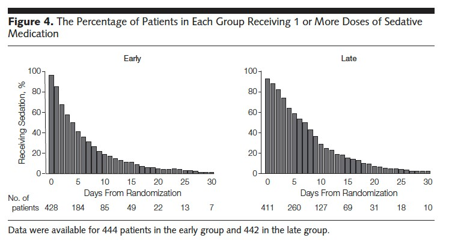

- [Terragni et al. 2010](https://jamanetwork.com/journals/jama/fullarticle/185688): lower rate of VAP in early tracheostomy (14 vs 21%)

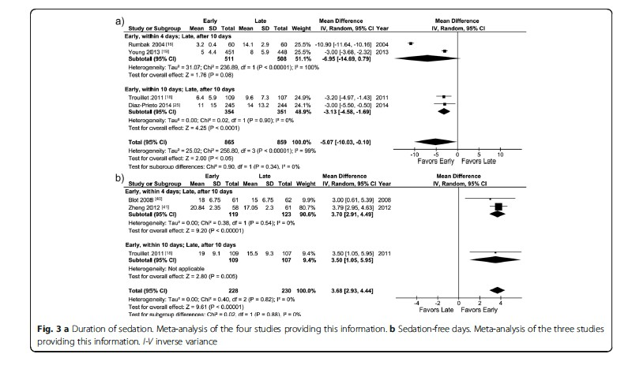

- [Abe et al. 2018](https://ccforum.biomedcentral.com/articles/10.1186/s13054-018-2126-6): LUNG SAFE data sub-study focused on ARDS
  - 13% of ARDS patients received a tracheostomy
  - 20-25% had severe ARDS on day 1
  - Median timing of trach was 14 days
  - 30% received trach within 7 days with no difference in outcome comparing early vs late
  - Trach was associated with a significantly longer ICU stay and number of days on a ventilator

# END OF LIFE CONSIDERATIONS

Please review “Ethical Guidance for BMC during COVID-19 Pandemic” distributed recently (link to final draft forthcoming)

### Important contact information

- Ethics pager: 4636
- Legal pager: 1523
- Patient advocate pager: 7178
- Palliative care pager: 0179

### Current visitor policy

- No visitors permitted on inpatient units and ED
- Care team can make a visitor exception
  - Visitor must be over 18, and will be screened for COVID-19 symptoms

### On arrival for all patients

- Confirm patient code status, document details in note
- Priority to establish HCP early, with accurate contact information
- Designate (with guidance of pt/HCP) one “contact person” for family/friends

### Goals of Care in Patients at High Risk of Death

- CPR may not offer benefit for COVID-19 patients, particularly those with advanced age (>80 years old) and/or comorbid cardiovascular disease, diabetes, hypertension, and respiratory disease.
- Performing CPR on patients with COVID-19 will increase transmission to healthcare workers, threatening their own well-being and reducing their availability to treat future patients.
- Attending physicians are not obligated to offer or provide CPR if resuscitative treatment would be medically inappropriate, even at the request of a patient or legally authorized representative.
- In patients with COVID-19 the risks to healthcare providers of performing CPR may influence a determination that CPR is not medically appropriate, if coupled with considerations of individual patient’s prognosis.

### Palliative Care

With the expected increase need for palliative care services, we will need to efficiently utilize the BMC palliative care team.

#### Self-education

- Prior to COVID team service, consider reviewing educational materials/modules recommended by palliative care service.
  - [Center to Advance Palliative Care](https://www.capc.org/)
    - Modules: Communication skills and Advanced Care Planning
  - [Palliative Care Network of Wisconsin](https://www.mypcnow.org/fast-facts/)
    - “Just in time” education on a variety of palliative care topics
  - [VITAL talk](https://www.vitaltalk.org/guides/covid-19-communication-skills/)
    - COVID-19 specific talking points and patient conversation aids

#### Palliative care service

- When making a palliative care service consult, the palliative care service will work with the primary team to determine the level of care needed by the team, ranging from tips/suggestions to full outreach to patient/family.
- Triggers for palliative care consult
  - Pre-existing palliative care patient
  - Symptoms refractory to palliative symptom protocols
  - On ventilatory support
  - Difficult-to-control emotional symptoms
  - Patient, family, or physician uncertainty regarding prognosis
  - Patient, family, or physician uncertainty regarding non-beneficial treatment options
  - Patient or family psychological or spiritual/existential distress
  - Patient or family request
- If you feel particularly comfortable having end of life, or other difficult conversations with patients/families, please consider reaching out to the palliative care team about being a “palliative care champion” to learn how to train colleagues.

### ACLS

#### Preparation

- A member of the primary team should meet with nursing/RT team at beginning of every shift to identify patients at high risk for arrest, make an action plan in case it occurs
- For high risk patients, consider having pre-filled syringe of epinephrine/atropine ready at the bedside
- If ACLS unlikely to be beneficial, discuss with patient/family to see if adjustment in code status is appropriate (frequent re-evaluation). See above section regarding physician decision to not offer CPR, particularly in patients on multiple pressors, receiving CVVH, and/or proned.
- Always take time to apply PPE. There is **NO SITUATION** for which you should enter a COVID/PUI room without proper PPE
- Contact family/HCP early in code. If family members are in room, please escort them out of room.

#### Personnel

**Inside Room**  
All personnel in room must wear enhanced PPE – N95 or PAPR, face shield, gown and double gloves.

- First responder: continue CPR while others enter, can then transition to one of the roles below
- Code leader/Primary Physician (walkie-talkie if available)
- Patient’s RN: administer medications, manage defibrillator, and update leader regarding changes in cardiac rhythm
- Airway expert physician: only if airway needed (airway team should be notified of code)
- Respiratory therapist
- Two additional RNs: assist with CPR and any other activities in room, can substitute house officer for one RN if needed

**Anteroom**

**Outside room, not in anteroom** (6+ ft from door opening)

- Additional “code-whisperer”" physicians with walkie-talkie (if available) to communicate inside the room
- RN for documentation and time-keeping
- Pharmacist
- RT on standby, ready to don PPE and replace RT in room
- Runner to assist with supply of equipment on the unit and activation of other HCW if required by team inside room
- Logistic officer (charge nurse, intensivist, senior medical resident)

#### Equipment

Limit single-use equipment entering room, as it will need to be discarded if not used

**Inside Room**

- Defibrillator
- Backboard for CPR
- Intubation equipment
- Manual resuscitation bag with bacterial/viral ENVE filter placed between mask/endotracheal tube and the bag
- Mechanical ventilator (if in ED or ICU)

**Passing Items into Room**

- RN outside room prepares item to enter room, opens door slightly, and using gloved hand passes item to person inside room without touching anything in the room.
- Only critical patient specimens should leave the room during the code.
- Samples should be wiped down by team in room. Door opened slightly by outside RN, and using gloved hand and wipe, outside RN takes sample from room. Sample is decontaminated again outside room, and placed in biohazard bag.
- Unless wearing enhanced PPE, outside RN then performs hand hygiene with alcohol gel, removes gloves and washes hands.
- **No other items should leave the room until the end of the code**. This enables decontamination in a controlled fashion without distractions.

**Outside Room**

- Videolaryngoscope (brought in to room at request of anesthesiology)
- Difficult airway cart
- Bronchoscope

#### Modifications to ACLS

In general, the goal is to limit the aerosolization of respiratory secretions while still providing excellent ACLS. Any recommendations in this section should superseded by anesthesia department policies on airway management in COVID-19 patients

- Intubate patients early and hold CPR during intubation to minimize aerosolization
- Pre-oxygenation
- minimize techniques that can aerosolize droplet
- NRB mask with filter and FiO2 is preferred
- Avoid manual ventilation before intubation
- Avoid coughing or becoming agitated (rapid sequence intubation)
- Immediately connect patient to resuscitation bag + filter, or mechanical ventilator and inline suction catheter.
- For intubated patients
- Increase FiO2 to 100%
- Leave patients on vent during CPR and RT stabilize connection to vent and monitors for administered breaths
- RT to instruct compressors to pause compressions for vent-administered breath, this limits possibility of patient becoming disconnected from vent and aerosolizing respiratory secretions
- For proned patients CPR may be performed by first responder over thoracic spine with bed on full inflate. Once RNs in PPE have arrived in room, the first priority is to turn the patient supine

#### After End of Code

**Inside Room**

- Take time to carefully doff PPE (best to have a doffing buddy)
- All non-disposable equipment must be decontaminated per BMC protocols
- All disposable equipment must be discarded

**Outside Room**

- If note made of any break in PPE, have employee immediately contact supervisor and fill out the Exposure Form from Working Well Clinic.
- Hot debrief to identify lessons learned. Identify who will document recommendations and forward on to nursing and medical leadership
- Involved personnel may take a “work pause” after debrief
- Consider changing scrubs
- Take some time to decompress
- Environmental services should be notified of a COVID-19 positive room and instructed to clean room and region surrounding room.

# PULMONARY DISEASE & COVID-19

## Asthma

### Association between Asthma and COVID-19

There is limited data at this time regarding whether asthma is a specific risk factor for COVID-19 infection, or increased pathology in asthma patients with COVID-19.

- No increased risk for severe COVID-19 among asthma patients in early studies from China
- Among United States cases, there is an association between “chronic lung disease” and hospitalization from COVID-19.
- Insufficient evidence to determine whether COVID-19 infection increases risk for acute asthma exacerbations

### Routine management of Asthma Patients

It is crucial to maintain good asthma control to limit their exposure to COVID-19 in clinical settings

- Encourage patients to self-isolate and practice social distancing.
- Maintain all asthma control medications, specifically inhaled corticosteroids and biologic agents (omalizumab and mepolizumab).
- If a patient using nebulized medications regularly at home, consider doing so away from individuals who may be at higher risk of complications from COVID-19 (ie elderly family members)
- Continue to support the use of asthma controlling medications by facilitating access to the medications in pharmacy, as well as prioritizing administration of biologic agents via clinic visits.
- Encourage the transition of routine and urgent clinic visits for asthma management to televisits.

### Management of asthma excerbations

Pharmacologic strategy for the treatment for acute asthma exacerbations should not change, *regardless of COVID-19 status*

- Promptly utilize systemic corticosteroids (e.g., 0.5-1mg/kg prednisone) for all patients with acute asthma exacerbations
- Continue to administer standing and PRN bronchodilators
  - For hospitalized patients with COVID-19+ or PUI, and symptoms of asthma exacerbation, do not administer nebulized medications, administer bronchodilators via metered dose inhaler (MDI). When substituted for a nebulizer treatment, the dose of albuterol MDI is 4 to 8 inhalations, administered as separate inhalations with a valved holding chamber.
  - Consult pharmacy on recommendations for ways to efficiently use MDI and preserve current hospital supplies, e.g., having patients bring in home medications.
- In general, non-invasive ventilation (i.e., BPAP, NIV) is discouraged in patients with COVID-19 outside of a negative pressure room, due to aerosolization of the virus and risk to staff and non-COVID patients. Patients with asthma exacerbations who may need more than nasal cannula support should have MICU consultation.

## COPD

### Routine management of COPD Patients

It is crucial to maintain good symptom control in COPD patients to limit their exposure to COVID-19 in clinical settings

- Encourage patients to self-isolate and practice social distancing.
- Maintain all usual COPD medications, including inhaled corticosteroids, systemic steroids, bronchodilators and supplemental O2.
- Continue to support the use of COPD controller medications by facilitating access to the medications in pharmacy.
- If a patient uses nebulized medications regularly at home, consider doing so away from individuals who may be at higher risk of complications from COVID-19 (ie elderly family members).
- Encourage the transition of routine and urgent clinic visits for COPD management to televisits.

### Management of COPD exacerbations

Pharmacologic strategy for the treatment for acute COPD exacerbations should not change, regardless of COVID-19 status

- Promptly utilize systemic corticosteroids (e.g, 0.5-1mg kg prednisone) for all patients with acute COPD exacerbations
- Continue to administer standing and PRN bronchodilators
  - For patients with COVID-19 and PUI, and symptoms of COP exacerbation, do not administer nebulized medications, administer via MDI. When substituted for a nebulizer treatment, the dose of albuterol MDI is 4 to 8 inhalations, administered as separate inhalations with a valved holding chamber. The dose of ipratropium MDI is 4 to 8 inhalations, also by valved holding chamber.
  - Consult pharmacy on recommendations for ways to efficiently use MDI and preserve current hospital supplies, , e.g., having patients bring in home medications.
- In general, non-invasive ventilation (i.e., BPAP, NIV) is discouraged in patients with COVID-19 outside of a negative pressure room, due to aerosolization of the virus and risk to staff and non-Covid+ patients. Patients with asthma exacerbations who may need more than nasal cannula support should trigger MICU consultation.

## Pulmonary Hypertension

### Association between Pulmonary Hypertension and COVID-19

There is no mention of pulmonary hypertension and COVID-19 in the medical literature

- Assume patients with pulmonary hypertension are a high-risk population:
  1. Many have co-existent CHF (right or left-sided)
  2. Increased risk for immunosuppression – connective tissue disease, sarcoidosis, sickle cell disease
  3. Often have co-existent lung disease – Group 3 PH

### Outpatient management of PAH issues related to COVID-19

Contact Liz Klings

## Sickle Cell Disease

Latest guidelines from SCDAA/ASH can be found [here](https://www.sicklecelldisease.org/2020/03/18/sickle-cell-disease-and-covid-19-provider-directory/)

- Transition outpatient care from in-person to telephonic when at all possible
- Monitor for signs of Acute Chest Syndrome (ACS): thrombocytopenia, AKI, hepatic dysfunction, altered mental status, and multi-organ failure. These are all present with both COVID and acute chest syndrome. Consult the sickle cell hematology team early in sickle cell patients with COVID-19
- Transfusion recommendations: Because of the anticipated blood shortage, we are not recommending exchange transfusion or the usual goal Hb > 9.0 g/dl. We now recommend initiation of simple transfusion with goal Hb 7 given current blood shortage with consultation with hematology for higher targets or exchange transfusion.

## Lung Cancer and Lung Cancer Screening

### Patients eligible for lung cancer screening

#### Recommendations

- Routine lung cancer screening (initial screening, annual screening, 12 month follow up screening) should be deferred.
- Patient with an existing abnormal lung cancer screening exam should be triaged based on the exam findings.
  - LungRads 1, 2: Delay annual screening
  - LungRads 3: Consider delaying re-imaging by 3-6 months
  - LungRads 4A, 4B, 4X: Refer to Lung Nodule Clinic for telemedicine visit to discuss multi-disciplinary recommendations

### Patients with lung nodules

#### Recommendations

- Consider delaying routine 6 month or 12 month follow up CT imaging for previously detected lung nodules or stable lung nodules.
- Consider delaying re-imaging of previous CT findings thought to represent inflammatory or infectious processes if the patient is asymptomatic.
- Consider re-imaging as recommended for patients with prior CT findings concerning for lung malignancy (3 month CT recommended and suspicion for malignancy; PET) provided that hospital capacity permits (see below for patients with suspected lung cancer).

#### Rationale

There are currently no published guidelines on management of CT Lung Screening or Pulmonary Nodules during the COVID-19 pandemic. These recommendations aim to balance the risk of a patient being harmed by nosocomial infections, including novel coronavirus, and being harmed by late-detection of a potential cancer that might reduce the chance of cure. Most non-small cell lung cancers (NSCLC) have a doubling time of approximately 3-6 months, though a subset may have much faster progression. Cancerous pulmonary nodules grow relatively quickly compared to other types of cancer (e.g. prostate, breast), making management of patients with suspected lung cancer a special consideration.

### Patients with known or suspected lung cancer

#### Recommendations

- Conduct proactive and early advance care planning discussions for patients with co-existent cancer and COVID-19. These patients are at higher risk for serious illness (e.g. invasive ventilation, ICU stay) and death. Seek input from palliative care and/or ethics as needed.
- Consider holding lung cancer chemotherapy or immunotherapy for hospitalized patients with active COVID-19.
- Multi-disciplinary discussion (e.g. Thoracic Tumor Board) is suggested for all patients with new or suspected lung cancer in order to obtain a consensus recommendation for management that balances the relative benefits and harms of various approaches. Contact Mary Clancy NP (mary.clancy@bmc.org) to arrange this. Specific guidance on thoracic surgical recommendations depend on the hospital phase of the pandemic, and include:
  - **Phase 1**: Few COVID-19 patients, hospital resources not exhausted, institution still has ICU vent capacity, and COVID trajectory not in rapid escalation phase; Surgery restricted to patients likely to have survivorship compromised if surgery not performed within next 3 months
    - Cases that need to be done as soon as feasible (recognizing status of the hospital is likely to progress over next few weeks):
      1. Solid or predominantly solid (>50%) lung cancer or presumed lung cancer >2cm, clinical node negative
      2. Node positive lung cancer
      3. Post induction therapy cancer
      4. Staging to start treatment (mediastinoscopy, diagnostic VATS for pleural dissemination)
      5. Patients enrolled in therapeutic clinical trials
    - Cases that should be deferred
      1. Predominantly ground glass (<50% solid) nodules or cancers
      2. Solid nodule or lung cancer < 2 cm
      3. Indolent histology (e.g. carcinoid, slowly enlarging nodule)
      4. Pulmonary Oligometastases - unless clinically necessary for pressing therapeutic or diagnostic indications (i.e. surgery will impact treatment)
      5. Patients unlikely to separate from mechanical ventilation or likely to have prolonged ICU needs (i.e. particularly high-risk patients)
  - **Phase 2**: Many COVID-19 patients, ICU and ventilator capacity limited, OR supplies limited or COVID-19 trajectory within hospital in rapidly escalating phase; Surgery restricted to patients likely to have survivorship compromised if surgery not performed within next few days
  - **Phase 3**: Hospital resources are all routed to COVID-19 patients, no ventilator or ICU capacity, OR supplies exhausted; Surgery restricted to patients likely to have survivorship compromised if surgery not performed within next few hours
- Initiation of chemotherapy or immunotherapy for patients with lung cancer and COVID-19 will be made on a case-by-case basis depending on clinical urgency and treatment options. Consults by medical oncology will continue in a timely manner, with telemedicine consults used where possible/appropriate.
- Radiation therapy (ongoing or new) for patients with lung cancer and COVID-19 will be made on a case-by-case basis depending on clinical urgency and other treatment options. Consults for radiation therapy will continue in a timely manner, with telemedicine consults used where possible/appropriate.

#### Rationale

Patients with cancer and COVID-19 are at higher risk for severe events including invasive ventilation, ICU admission, and death (HR 3.56). Recent treatment and age were associated with more severe events. Patients with cancer and COVID-19 also appeared to deteriorate more rapidly. Although there is one case report of a 57 year old man with EGFR-mutant NSCLC on osimertinib admitted with SARS-CoV-2 in whom immunotherapy was continued, we do not routinely recommend this approach given other data suggesting that recent therapy across all cancers was associated with more severe COVID19-related events. Considerations regarding surgical resection, chemotherapy, or radiation of therapy for lung cancers of lung cancers aim to balance the risk of infection, including COVID-19, with the risk of reducing chance of cure, and hospital resources that are available based on the phase of the pandemic. While delaying start dates for chemotherapy and/or radiation therapy has quickly become routine practice nation-wide for certain cancers with good prognosis (e.g. early-stage breast cancer, prostate cancer), given the worse prognosis of lung cancer most should be treated in a timely manner. Again, these decisions will be made on a case-by-case basis after multidisciplinary discussion.

##### References

[ACS COVID-19 guidelines](https://www.facs.org/covid-19/clinical-guidance/elective-case/thoracic-cancer)  
Cortiula et al. 2020  
Krengli et al. 2020  
[Ueda et al. 2020](https://jnccn.org/view/journals/jnccn/aop/article-10.6004-jnccn.2020.7560/article-10.6004-jnccn.2020.7560.xml)  
Liang et al. 2020  
Zhang et al. 2020

## Sarcoidosis

### Association between Sarcoidosis and COVID-19

There is no medical literature to guide the management of sarcoidosis patients with COVID-19. Our sarcoidosis is joining a multi-center registry, and we will share any new information/guidance as it becomes available. Contact pulmonary consult with any additional questions/concerns

### Outpatient management of Sarcoidosis issues related to COVID-19

- Encourage patients to self-isolate and practice social distancing.
- As much as possible, transition clinical visits to televisits to limit patient exposure to medical facilities and increased risk of transmission
- Patients who are not infected with COVID-19
  - Do not alter current regimen unless directed to do so by the team in the sarcoidosis clinic
- Patients who are sick with COVID-19 but do not require hospitalization
  - Do not change medication unless directed to do so by the sarcoidosis clinic
- Please inform sarcoidosis clinic of patient’s diagnosis, so that they can check in with the patient
- Patients who are sick with COVID-19 and require hospitalization
  - For patients on methotrexate/anti-TNF agents – stop medication
  - For patients on hydroxychloroquine – continue medication

## Obstructive Sleep Apnea (OSA)

### Home: Patients who use CPAP or Bilevel PAP or ASV devices

If there is concern that a patient may be infected with COVID-19 coronavirus, continuation of PAP therapy depends on several factors (e.g apnea severity, high-risk household members, ability to sleep in a separate room). If a patient with COVID-19 continues to use PAP therapy, recommend he/she sleep in a separate room from other household members.

Regional Home Care (RHC) is continuing to set up and troubleshoot mask and machine issues by conducting telemedicine calls and on-site visits in select patients.

### Hospitalization: Patients who use CPAP or Bilevel PAP or ASV devices

The use of PAP therapy in patients who are infected with COVID-19 may lead to increased aerosolization of the infectious droplets, leading to greater transmission to healthcare workers. We therefore do not recommend usage of PAP therapy in patients who are hospitalized and have symptoms/signs of COVID-19. Use of nocturnal oxygen is recommended.

# COMMUNICATION

Communication is crucial to the successful delivery of safe and effective clinical services.

Information management plans should be established for effective and consistent dissemination of information to relevant stakeholders. These should include daily situation reports and regular updates on unit, organizational, regional and state responses.

A variety of information dissemination methods should be considered to account for physical distancing needed for infection control purposes. These may involve video and teleconferencing, and electronic communication platforms.

Effective lines of communication must be established to ensure that stakeholders are apprised of evolving clinical scenarios and changes in clinical practice guidelines and processes. ICU load and capacity must be measured in real-time and communicated to relevant in-hospital administrative and jurisdictional authorities. It is vital to track both patient outcomes and staff well-being. Specific stakeholders and considerations may include:

- Organizational chains of command
- State and national health authorities
- Inter-departmental communications
- Staff

# OTHER RESOURCES

[BMC COVID-19 Information for Employees](https://www.bmc.org/covid-19-information-employees/)  
[BMC MICU COVID-19 BOX Folder](https://bostonmedical.app.box.com/s/ucdf0piv2usfyr9iqnk2coccmn1afbwo/folder/107007254570) requires BMC login  
[Society of Critical Care Medicine Recommendations](https://sccm.org/getattachment/Disaster/SSC-COVID19-Critical-Care-Guidelines.pdf?lang=en-US&_zs=SgWjd1&_zl=k1cc6)  
WHO Treatment Recommendations Severe COVID-19  
[UpToDate COVID-19](https://www.uptodate.com/contents/coronavirus-disease-2019-covid-19?source=history_widget)  
[Sickle Cell Disease and COVID-19](https://www.sicklecelldisease.org/files/sites/181/2020/03/SCDAA-PROVIDER-ADVISORY4-3-25-20-v2.pdf)